# Optimal Treatment Analysis

## Outcome Variable

**Outcome Variable:** haz

## Predictor Variables

**Intervention Variable:** anywast06

**Adjustment Set:**

- arm
- sex
- brthmon
- W_mage
- meducyrs
- hhwealth_quart
- W_nrooms
- month
- W_parity
- delta_W_mage
- delta_meducyrs
- delta_hhwealth_quart
- delta_W_nrooms
- delta_month
- delta_W_parity

## Stratifying Variables

The analysis was stratified on these variable(s):

- agecat
- studyid
- country

## Data Summary

| agecat | studyid | country | anywast06 | n_cell | n |
| --- | --- | --- | --- | --- | --- |
| Birth | ki0047075b-MAL-ED | BANGLADESH | 0 | 177 | 229 |
| Birth | ki0047075b-MAL-ED | BANGLADESH | 1 | 52 | 229 |
| Birth | ki0047075b-MAL-ED | BRAZIL | 0 | 62 | 65 |
| Birth | ki0047075b-MAL-ED | BRAZIL | 1 | 3 | 65 |
| Birth | ki0047075b-MAL-ED | INDIA | 0 | 33 | 47 |
| Birth | ki0047075b-MAL-ED | INDIA | 1 | 14 | 47 |
| Birth | ki0047075b-MAL-ED | NEPAL | 0 | 23 | 27 |
| Birth | ki0047075b-MAL-ED | NEPAL | 1 | 4 | 27 |
| Birth | ki0047075b-MAL-ED | PERU | 0 | 223 | 233 |
| Birth | ki0047075b-MAL-ED | PERU | 1 | 10 | 233 |
| Birth | ki0047075b-MAL-ED | SOUTH AFRICA | 0 | 101 | 122 |
| Birth | ki0047075b-MAL-ED | SOUTH AFRICA | 1 | 21 | 122 |
| Birth | ki0047075b-MAL-ED | TANZANIA, UNITED REPUBLIC OF | 0 | 119 | 124 |
| Birth | ki0047075b-MAL-ED | TANZANIA, UNITED REPUBLIC OF | 1 | 5 | 124 |
| Birth | ki1000108-CMC-V-BCS-2002 | INDIA | 0 | 37 | 92 |
| Birth | ki1000108-CMC-V-BCS-2002 | INDIA | 1 | 55 | 92 |
| Birth | ki1000108-IRC | INDIA | 0 | 164 | 388 |
| Birth | ki1000108-IRC | INDIA | 1 | 224 | 388 |
| Birth | ki1000109-EE | PAKISTAN | 0 | 156 | 240 |
| Birth | ki1000109-EE | PAKISTAN | 1 | 84 | 240 |
| Birth | ki1000109-ResPak | PAKISTAN | 0 | 28 | 42 |
| Birth | ki1000109-ResPak | PAKISTAN | 1 | 14 | 42 |
| Birth | ki1017093b-PROVIDE | BANGLADESH | 0 | 396 | 539 |
| Birth | ki1017093b-PROVIDE | BANGLADESH | 1 | 143 | 539 |
| Birth | ki1101329-Keneba | GAMBIA | 0 | 994 | 1542 |
| Birth | ki1101329-Keneba | GAMBIA | 1 | 548 | 1542 |
| Birth | ki1113344-GMS-Nepal | NEPAL | 0 | 422 | 684 |
| Birth | ki1113344-GMS-Nepal | NEPAL | 1 | 262 | 684 |
| Birth | ki1114097-CMIN | BANGLADESH | 0 | 15 | 20 |
| Birth | ki1114097-CMIN | BANGLADESH | 1 | 5 | 20 |

[output cut: 70 more lines]

The following strata were considered:

- agecat: 24 months, studyid: ki0047075b-MAL-ED, country: BANGLADESH
- agecat: 24 months, studyid: ki0047075b-MAL-ED, country: BRAZIL
- agecat: 24 months, studyid: ki0047075b-MAL-ED, country: INDIA
- agecat: 24 months, studyid: ki0047075b-MAL-ED, country: NEPAL
- agecat: 24 months, studyid: ki0047075b-MAL-ED, country: PERU
- agecat: 24 months, studyid: ki0047075b-MAL-ED, country: SOUTH AFRICA
- agecat: 24 months, studyid: ki0047075b-MAL-ED, country: TANZANIA, UNITED REPUBLIC OF
- agecat: 24 months, studyid: ki1000108-CMC-V-BCS-2002, country: INDIA
- agecat: 24 months, studyid: ki1000108-IRC, country: INDIA
- agecat: 24 months, studyid: ki1000109-EE, country: PAKISTAN
- agecat: 24 months, studyid: ki1017093b-PROVIDE, country: BANGLADESH
- agecat: 24 months, studyid: ki1066203-TanzaniaChild2, country: TANZANIA, UNITED REPUBLIC OF
- agecat: 24 months, studyid: ki1101329-Keneba, country: GAMBIA
- agecat: 24 months, studyid: ki1113344-GMS-Nepal, country: NEPAL
- agecat: 24 months, studyid: ki1114097-CMIN, country: BANGLADESH
- agecat: 24 months, studyid: ki1114097-CONTENT, country: PERU
- agecat: 6 months, studyid: ki0047075b-MAL-ED, country: BANGLADESH
- agecat: 6 months, studyid: ki0047075b-MAL-ED, country: BRAZIL
- agecat: 6 months, studyid: ki0047075b-MAL-ED, country: INDIA
- agecat: 6 months, studyid: ki0047075b-MAL-ED, country: NEPAL
- agecat: 6 months, studyid: ki0047075b-MAL-ED, country: PERU
- agecat: 6 months, studyid: ki0047075b-MAL-ED, country: SOUTH AFRICA
- agecat: 6 months, studyid: ki0047075b-MAL-ED, country: TANZANIA, UNITED REPUBLIC OF
- agecat: 6 months, studyid: ki1000108-CMC-V-BCS-2002, country: INDIA
- agecat: 6 months, studyid: ki1000108-IRC, country: INDIA
- agecat: 6 months, studyid: ki1000109-EE, country: PAKISTAN
- agecat: 6 months, studyid: ki1000109-ResPak, country: PAKISTAN
- agecat: 6 months, studyid: ki1017093b-PROVIDE, country: BANGLADESH
- agecat: 6 months, studyid: ki1066203-TanzaniaChild2, country: TANZANIA, UNITED REPUBLIC OF
- agecat: 6 months, studyid: ki1101329-Keneba, country: GAMBIA
- agecat: 6 months, studyid: ki1112895-Guatemala BSC, country: GUATEMALA
- agecat: 6 months, studyid: ki1113344-GMS-Nepal, country: NEPAL
- agecat: 6 months, studyid: ki1114097-CMIN, country: BANGLADESH
- agecat: 6 months, studyid: ki1114097-CONTENT, country: PERU
- agecat: Birth, studyid: ki0047075b-MAL-ED, country: BANGLADESH
- agecat: Birth, studyid: ki0047075b-MAL-ED, country: BRAZIL
- agecat: Birth, studyid: ki0047075b-MAL-ED, country: INDIA
- agecat: Birth, studyid: ki0047075b-MAL-ED, country: NEPAL
- agecat: Birth, studyid: ki0047075b-MAL-ED, country: PERU
- agecat: Birth, studyid: ki0047075b-MAL-ED, country: SOUTH AFRICA
- agecat: Birth, studyid: ki0047075b-MAL-ED, country: TANZANIA, UNITED REPUBLIC OF
- agecat: Birth, studyid: ki1000108-CMC-V-BCS-2002, country: INDIA
- agecat: Birth, studyid: ki1000108-IRC, country: INDIA
- agecat: Birth, studyid: ki1000109-EE, country: PAKISTAN
- agecat: Birth, studyid: ki1000109-ResPak, country: PAKISTAN
- agecat: Birth, studyid: ki1017093b-PROVIDE, country: BANGLADESH
- agecat: Birth, studyid: ki1101329-Keneba, country: GAMBIA
- agecat: Birth, studyid: ki1113344-GMS-Nepal, country: NEPAL
- agecat: Birth, studyid: ki1114097-CMIN, country: BANGLADESH
- agecat: Birth, studyid: ki1114097-CONTENT, country: PERU

### Dropped Strata

Some strata were dropped due to rare outcomes:

- agecat: Birth, studyid: ki0047075b-MAL-ED, country: BRAZIL
- agecat: Birth, studyid: ki0047075b-MAL-ED, country: NEPAL
- agecat: Birth, studyid: ki1114097-CONTENT, country: PERU
- agecat: 6 months, studyid: ki1114097-CONTENT, country: PERU
- agecat: 24 months, studyid: ki1066203-TanzaniaChild2, country: TANZANIA, UNITED REPUBLIC OF
- agecat: 24 months, studyid: ki1114097-CONTENT, country: PERU

## Methods Detail

We’re interested in the causal parameters $E[Y_a]$ for all values of $a \in \mathcal{A}$. These parameters represent the mean outcome if, possibly contrary to fact, we intervened to set all units to have $A=a$. Under the randomization and positivity assumptions, these are identified by the statistical parameters $\psi_a=E_W[E_{Y|A,W}(Y|A=a,W)]$. In addition, we’re interested in the mean of $Y$, $E[Y]$ under no intervention (the observed mean). We will estimate these parameters by using SuperLearner to fit the relevant likelihood factors – $E_{Y|A,W}(Y|A=a,W)$ and $p(A=a|W)$, and then updating our likelihood fit using a joint TMLE.

For unadjusted analyses ($W=\{\}$), initial likelihoods were estimated using Lrnr_glm to estimate the simple $E(Y|A)$ and Lrnr_mean to estimate $p(A)$. For adjusted analyses, a small library containing Lrnr_glmnet, Lrnr_xgboost, and Lrnr_mean was used.

# Results Detail

## Results Plots

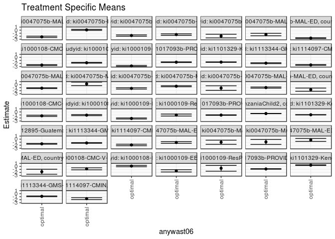

## Results Table

### Parameter: TSM

| agecat | studyid | country | intervention_level | baseline_level | estimate | ci_lower | ci_upper |
| --- | --- | --- | --- | --- | --- | --- | --- |
| Birth | ki0047075b-MAL-ED | BANGLADESH | optimal | observed | -1.1006669 | -1.3830208 | -0.8183130 |
| Birth | ki0047075b-MAL-ED | INDIA | optimal | observed | -1.0089783 | -1.6879007 | -0.3300559 |
| Birth | ki0047075b-MAL-ED | PERU | optimal | observed | -0.9199760 | -1.7349543 | -0.1049976 |
| Birth | ki0047075b-MAL-ED | SOUTH AFRICA | optimal | observed | -0.2593333 | -0.7454647 | 0.2267981 |
| Birth | ki0047075b-MAL-ED | TANZANIA, UNITED REPUBLIC OF | optimal | observed | -1.7511674 | -2.5744035 | -0.9279314 |
| Birth | ki1000108-CMC-V-BCS-2002 | INDIA | optimal | observed | -0.7971600 | -1.1336394 | -0.4606805 |
| Birth | ki1000108-IRC | INDIA | optimal | observed | 0.1128413 | -0.1035979 | 0.3292804 |
| Birth | ki1000109-EE | PAKISTAN | optimal | observed | -1.4630595 | -1.8401828 | -1.0859362 |
| Birth | ki1000109-ResPak | PAKISTAN | optimal | observed | -0.6183737 | -1.5658520 | 0.3291046 |
| Birth | ki1017093b-PROVIDE | BANGLADESH | optimal | observed | -0.8429295 | -0.9373213 | -0.7485377 |
| Birth | ki1101329-Keneba | GAMBIA | optimal | observed | 0.4120072 | 0.3002736 | 0.5237408 |
| Birth | ki1113344-GMS-Nepal | NEPAL | optimal | observed | -0.8764752 | -0.9977167 | -0.7552337 |
| Birth | ki1114097-CMIN | BANGLADESH | optimal | observed | -1.6399700 | -1.9501798 | -1.3297602 |
| 6 months | ki0047075b-MAL-ED | BANGLADESH | optimal | observed | -1.1641980 | -1.2898273 | -1.0385688 |
| 6 months | ki0047075b-MAL-ED | BRAZIL | optimal | observed | 0.2448457 | -0.3405268 | 0.8302183 |
| 6 months | ki0047075b-MAL-ED | INDIA | optimal | observed | -1.2432955 | -1.4632002 | -1.0233909 |
| 6 months | ki0047075b-MAL-ED | NEPAL | optimal | observed | -0.5257134 | -0.6980143 | -0.3534124 |
| 6 months | ki0047075b-MAL-ED | PERU | optimal | observed | -1.1380867 | -1.8842875 | -0.3918858 |
| 6 months | ki0047075b-MAL-ED | SOUTH AFRICA | optimal | observed | -0.9688196 | -1.1691398 | -0.7684994 |
| 6 months | ki0047075b-MAL-ED | TANZANIA, UNITED REPUBLIC OF | optimal | observed | -1.6485965 | -2.1821209 | -1.1150721 |
| 6 months | ki1000108-CMC-V-BCS-2002 | INDIA | optimal | observed | -1.2948322 | -1.4965586 | -1.0931058 |
| 6 months | ki1000108-IRC | INDIA | optimal | observed | -1.0728540 | -1.2503539 | -0.8953541 |
| 6 months | ki1000109-EE | PAKISTAN | optimal | observed | -2.1670214 | -2.3458120 | -1.9882307 |
| 6 months | ki1000109-ResPak | PAKISTAN | optimal | observed | -1.0391531 | -1.3667571 | -0.7115492 |
| 6 months | ki1017093b-PROVIDE | BANGLADESH | optimal | observed | -1.0449491 | -1.1304512 | -0.9594471 |
| 6 months | ki1066203-TanzaniaChild2 | TANZANIA, UNITED REPUBLIC OF | optimal | observed | -0.5393280 | -0.5922886 | -0.4863674 |
| 6 months | ki1101329-Keneba | GAMBIA | optimal | observed | -0.9433170 | -1.0058080 | -0.8808259 |
| 6 months | ki1112895-Guatemala BSC | GUATEMALA | optimal | observed | -1.5375701 | -1.6552688 | -1.4198715 |
| 6 months | ki1113344-GMS-Nepal | NEPAL | optimal | observed | -1.2557303 | -1.3707798 | -1.1406808 |
| 6 months | ki1114097-CMIN | BANGLADESH | optimal | observed | -1.9107414 | -2.1588526 | -1.6626301 |
| 24 months | ki0047075b-MAL-ED | BANGLADESH | optimal | observed | -2.2132909 | -2.4447512 | -1.9818306 |
| 24 months | ki0047075b-MAL-ED | BRAZIL | optimal | observed | 0.0772514 | -0.0855356 | 0.2400384 |
| 24 months | ki0047075b-MAL-ED | INDIA | optimal | observed | -1.7726737 | -1.9943556 | -1.5509918 |
| 24 months | ki0047075b-MAL-ED | NEPAL | optimal | observed | -1.4593623 | -1.7103352 | -1.2083893 |
| 24 months | ki0047075b-MAL-ED | PERU | optimal | observed | -1.9470545 | -2.5540151 | -1.3400939 |
| 24 months | ki0047075b-MAL-ED | SOUTH AFRICA | optimal | observed | -1.4466861 | -1.8599131 | -1.0334590 |
| 24 months | ki0047075b-MAL-ED | TANZANIA, UNITED REPUBLIC OF | optimal | observed | -2.6322152 | -2.7697851 | -2.4946453 |
| 24 months | ki1000108-CMC-V-BCS-2002 | INDIA | optimal | observed | -2.5223438 | -2.6647863 | -2.3799012 |
| 24 months | ki1000108-IRC | INDIA | optimal | observed | -1.7675258 | -1.8987112 | -1.6363403 |
| 24 months | ki1000109-EE | PAKISTAN | optimal | observed | -2.8278031 | -3.0128789 | -2.6427274 |
| 24 months | ki1017093b-PROVIDE | BANGLADESH | optimal | observed | -1.5798686 | -1.6801179 | -1.4796193 |
| 24 months | ki1101329-Keneba | GAMBIA | optimal | observed | -1.5548173 | -1.6311528 | -1.4784818 |
| 24 months | ki1113344-GMS-Nepal | NEPAL | optimal | observed | -1.9041220 | -2.0500594 | -1.7581846 |
| 24 months | ki1114097-CMIN | BANGLADESH | optimal | observed | -2.4872502 | -2.6256377 | -2.3488627 |

### Parameter: E(Y)

| agecat | studyid | country | intervention_level | baseline_level | estimate | ci_lower | ci_upper |
| --- | --- | --- | --- | --- | --- | --- | --- |
| Birth | ki0047075b-MAL-ED | BANGLADESH | observed | observed | -1.1041048 | -1.2383048 | -0.9699048 |
| Birth | ki0047075b-MAL-ED | INDIA | observed | observed | -1.2036170 | -1.4976814 | -0.9095527 |
| Birth | ki0047075b-MAL-ED | PERU | observed | observed | -0.8827897 | -1.0001058 | -0.7654736 |
| Birth | ki0047075b-MAL-ED | SOUTH AFRICA | observed | observed | -0.5877869 | -0.7622273 | -0.4133464 |
| Birth | ki0047075b-MAL-ED | TANZANIA, UNITED REPUBLIC OF | observed | observed | -1.1369355 | -1.3453337 | -0.9285373 |
| Birth | ki1000108-CMC-V-BCS-2002 | INDIA | observed | observed | -0.9611957 | -1.1776967 | -0.7446946 |
| Birth | ki1000108-IRC | INDIA | observed | observed | -0.3080412 | -0.4687931 | -0.1472894 |
| Birth | ki1000109-EE | PAKISTAN | observed | observed | -1.8608750 | -2.0482045 | -1.6735455 |
| Birth | ki1000109-ResPak | PAKISTAN | observed | observed | -0.9800000 | -1.4086438 | -0.5513562 |
| Birth | ki1017093b-PROVIDE | BANGLADESH | observed | observed | -0.8851020 | -0.9601332 | -0.8100709 |
| Birth | ki1101329-Keneba | GAMBIA | observed | observed | 0.0325486 | -0.0310420 | 0.0961393 |
| Birth | ki1113344-GMS-Nepal | NEPAL | observed | observed | -1.0454532 | -1.1235003 | -0.9674062 |
| Birth | ki1114097-CMIN | BANGLADESH | observed | observed | -1.2030000 | -1.6953191 | -0.7106809 |
| 6 months | ki0047075b-MAL-ED | BANGLADESH | observed | observed | -1.2049931 | -1.3222136 | -1.0877726 |
| 6 months | ki0047075b-MAL-ED | BRAZIL | observed | observed | 0.0475758 | -0.0963508 | 0.1915023 |
| 6 months | ki0047075b-MAL-ED | INDIA | observed | observed | -1.2115254 | -1.3298727 | -1.0931782 |
| 6 months | ki0047075b-MAL-ED | NEPAL | observed | observed | -0.5615819 | -0.6741832 | -0.4489807 |
| 6 months | ki0047075b-MAL-ED | PERU | observed | observed | -1.3236661 | -1.4316775 | -1.2156546 |
| 6 months | ki0047075b-MAL-ED | SOUTH AFRICA | observed | observed | -1.0633202 | -1.1909180 | -0.9357224 |
| 6 months | ki0047075b-MAL-ED | TANZANIA, UNITED REPUBLIC OF | observed | observed | -1.3687449 | -1.4907629 | -1.2467270 |
| 6 months | ki1000108-CMC-V-BCS-2002 | INDIA | observed | observed | -1.4241872 | -1.5668135 | -1.2815609 |
| 6 months | ki1000108-IRC | INDIA | observed | observed | -1.2344062 | -1.3658524 | -1.1029600 |
| 6 months | ki1000109-EE | PAKISTAN | observed | observed | -2.0835567 | -2.2027557 | -1.9643578 |
| 6 months | ki1000109-ResPak | PAKISTAN | observed | observed | -1.4314086 | -1.6374838 | -1.2253335 |
| 6 months | ki1017093b-PROVIDE | BANGLADESH | observed | observed | -1.0916915 | -1.1661176 | -1.0172654 |
| 6 months | ki1066203-TanzaniaChild2 | TANZANIA, UNITED REPUBLIC OF | observed | observed | -0.5434389 | -0.5924056 | -0.4944722 |
| 6 months | ki1101329-Keneba | GAMBIA | observed | observed | -0.9116762 | -0.9588660 | -0.8644864 |
| 6 months | ki1112895-Guatemala BSC | GUATEMALA | observed | observed | -1.5785476 | -1.6926664 | -1.4644288 |
| 6 months | ki1113344-GMS-Nepal | NEPAL | observed | observed | -1.3508392 | -1.4290633 | -1.2726152 |
| 6 months | ki1114097-CMIN | BANGLADESH | observed | observed | -1.7844376 | -1.9222926 | -1.6465825 |
| 24 months | ki0047075b-MAL-ED | BANGLADESH | observed | observed | -1.9783962 | -2.1050210 | -1.8517715 |
| 24 months | ki0047075b-MAL-ED | BRAZIL | observed | observed | 0.0061144 | -0.1625850 | 0.1748138 |
| 24 months | ki0047075b-MAL-ED | INDIA | observed | observed | -1.8861894 | -2.0110006 | -1.7613783 |
| 24 months | ki0047075b-MAL-ED | NEPAL | observed | observed | -1.3075877 | -1.4270718 | -1.1881037 |
| 24 months | ki0047075b-MAL-ED | PERU | observed | observed | -1.7524710 | -1.8736426 | -1.6312994 |
| 24 months | ki0047075b-MAL-ED | SOUTH AFRICA | observed | observed | -1.6450595 | -1.7797240 | -1.5103950 |
| 24 months | ki0047075b-MAL-ED | TANZANIA, UNITED REPUBLIC OF | observed | observed | -2.6455607 | -2.7807256 | -2.5103959 |
| 24 months | ki1000108-CMC-V-BCS-2002 | INDIA | observed | observed | -2.5489071 | -2.6476125 | -2.4502017 |
| 24 months | ki1000108-IRC | INDIA | observed | observed | -1.7987775 | -1.8923914 | -1.7051636 |
| 24 months | ki1000109-EE | PAKISTAN | observed | observed | -2.6699900 | -2.8138051 | -2.5261749 |
| 24 months | ki1017093b-PROVIDE | BANGLADESH | observed | observed | -1.6024221 | -1.6857420 | -1.5191023 |
| 24 months | ki1101329-Keneba | GAMBIA | observed | observed | -1.5774758 | -1.6295950 | -1.5253566 |
| 24 months | ki1113344-GMS-Nepal | NEPAL | observed | observed | -1.8874180 | -1.9728588 | -1.8019773 |
| 24 months | ki1114097-CMIN | BANGLADESH | observed | observed | -2.5109504 | -2.6361514 | -2.3857494 |

### Parameter: PAR

| agecat | studyid | country | intervention_level | baseline_level | estimate | ci_lower | ci_upper |
| --- | --- | --- | --- | --- | --- | --- | --- |
| Birth | ki0047075b-MAL-ED | BANGLADESH | optimal | observed | -0.0034379 | -0.2402441 | 0.2333683 |
| Birth | ki0047075b-MAL-ED | INDIA | optimal | observed | -0.1946387 | -0.7401050 | 0.3508276 |
| Birth | ki0047075b-MAL-ED | PERU | optimal | observed | 0.0371863 | -0.7444293 | 0.8188018 |
| Birth | ki0047075b-MAL-ED | SOUTH AFRICA | optimal | observed | -0.3284536 | -0.7648704 | 0.1079633 |
| Birth | ki0047075b-MAL-ED | TANZANIA, UNITED REPUBLIC OF | optimal | observed | 0.6142320 | -0.2016601 | 1.4301241 |
| Birth | ki1000108-CMC-V-BCS-2002 | INDIA | optimal | observed | -0.1640357 | -0.4392916 | 0.1112203 |
| Birth | ki1000108-IRC | INDIA | optimal | observed | -0.4208825 | -0.5578967 | -0.2838683 |
| Birth | ki1000109-EE | PAKISTAN | optimal | observed | -0.3978155 | -0.6897307 | -0.1059002 |
| Birth | ki1000109-ResPak | PAKISTAN | optimal | observed | -0.3616263 | -1.1222731 | 0.3990205 |
| Birth | ki1017093b-PROVIDE | BANGLADESH | optimal | observed | -0.0421726 | -0.1149140 | 0.0305688 |
| Birth | ki1101329-Keneba | GAMBIA | optimal | observed | -0.3794585 | -0.4674729 | -0.2914442 |
| Birth | ki1113344-GMS-Nepal | NEPAL | optimal | observed | -0.1689780 | -0.2667466 | -0.0712095 |
| Birth | ki1114097-CMIN | BANGLADESH | optimal | observed | 0.4369700 | -0.1045332 | 0.9784731 |
| 6 months | ki0047075b-MAL-ED | BANGLADESH | optimal | observed | -0.0407951 | -0.1167671 | 0.0351770 |
| 6 months | ki0047075b-MAL-ED | BRAZIL | optimal | observed | -0.1972700 | -0.7556423 | 0.3611023 |
| 6 months | ki0047075b-MAL-ED | INDIA | optimal | observed | 0.0317701 | -0.1409500 | 0.2044902 |
| 6 months | ki0047075b-MAL-ED | NEPAL | optimal | observed | -0.0358686 | -0.1673119 | 0.0955748 |
| 6 months | ki0047075b-MAL-ED | PERU | optimal | observed | -0.1855794 | -0.9090915 | 0.5379328 |
| 6 months | ki0047075b-MAL-ED | SOUTH AFRICA | optimal | observed | -0.0945006 | -0.2796623 | 0.0906611 |
| 6 months | ki0047075b-MAL-ED | TANZANIA, UNITED REPUBLIC OF | optimal | observed | 0.2798516 | -0.2401187 | 0.7998219 |
| 6 months | ki1000108-CMC-V-BCS-2002 | INDIA | optimal | observed | -0.1293550 | -0.2715030 | 0.0127930 |
| 6 months | ki1000108-IRC | INDIA | optimal | observed | -0.1615522 | -0.2772026 | -0.0459019 |
| 6 months | ki1000109-EE | PAKISTAN | optimal | observed | 0.0834646 | -0.0316867 | 0.1986159 |
| 6 months | ki1000109-ResPak | PAKISTAN | optimal | observed | -0.3922555 | -0.6434058 | -0.1411052 |
| 6 months | ki1017093b-PROVIDE | BANGLADESH | optimal | observed | -0.0467424 | -0.0921006 | -0.0013841 |
| 6 months | ki1066203-TanzaniaChild2 | TANZANIA, UNITED REPUBLIC OF | optimal | observed | -0.0041109 | -0.0249387 | 0.0167169 |
| 6 months | ki1101329-Keneba | GAMBIA | optimal | observed | 0.0316408 | -0.0096627 | 0.0729443 |
| 6 months | ki1112895-Guatemala BSC | GUATEMALA | optimal | observed | -0.0409775 | -0.0754366 | -0.0065184 |
| 6 months | ki1113344-GMS-Nepal | NEPAL | optimal | observed | -0.0951090 | -0.1823791 | -0.0078389 |
| 6 months | ki1114097-CMIN | BANGLADESH | optimal | observed | 0.1263038 | -0.0526946 | 0.3053022 |
| 24 months | ki0047075b-MAL-ED | BANGLADESH | optimal | observed | 0.2348946 | 0.0500041 | 0.4197852 |
| 24 months | ki0047075b-MAL-ED | BRAZIL | optimal | observed | -0.0711370 | -0.1493988 | 0.0071248 |
| 24 months | ki0047075b-MAL-ED | INDIA | optimal | observed | -0.1135157 | -0.2927952 | 0.0657638 |
| 24 months | ki0047075b-MAL-ED | NEPAL | optimal | observed | 0.1517745 | -0.0617315 | 0.3652805 |
| 24 months | ki0047075b-MAL-ED | PERU | optimal | observed | 0.1945835 | -0.4013527 | 0.7905197 |
| 24 months | ki0047075b-MAL-ED | SOUTH AFRICA | optimal | observed | -0.1983735 | -0.5803952 | 0.1836482 |
| 24 months | ki0047075b-MAL-ED | TANZANIA, UNITED REPUBLIC OF | optimal | observed | -0.0133456 | -0.0512128 | 0.0245216 |
| 24 months | ki1000108-CMC-V-BCS-2002 | INDIA | optimal | observed | -0.0265633 | -0.1276873 | 0.0745606 |
| 24 months | ki1000108-IRC | INDIA | optimal | observed | -0.0312517 | -0.1139724 | 0.0514689 |
| 24 months | ki1000109-EE | PAKISTAN | optimal | observed | 0.1578131 | 0.0311541 | 0.2844721 |
| 24 months | ki1017093b-PROVIDE | BANGLADESH | optimal | observed | -0.0225535 | -0.0663141 | 0.0212071 |
| 24 months | ki1101329-Keneba | GAMBIA | optimal | observed | -0.0226585 | -0.0758234 | 0.0305064 |
| 24 months | ki1113344-GMS-Nepal | NEPAL | optimal | observed | 0.0167040 | -0.0901257 | 0.1235336 |
| 24 months | ki1114097-CMIN | BANGLADESH | optimal | observed | -0.0237002 | -0.0803755 | 0.0329752 |